# Research of Potential Factors of the Bacterial Level of Water Quality

Jinyuan Qin 520145126

# 1 Executive Summary

# 2 Full Report

## 2.1 Initial Data Analysis (IDA)

### 2.1.1 IDA: Source

- The data came from the beachwatch water quality program of the NSW Department of Planning and Environment.The dataset shows that the level of enterococci of Sydney Northern beach in 2018.
- The data is valid because the source is come from the official dataset and the beachwatch water quality program has been hold since 1989, the program was expanded and more monitored sites built. The program dataset provides the regular and reliable water quality information.
- Possible issues include this dataset only shows that the water quality of 2018, actually when I see the report of 2021 water quality report, the water quality is decreasing a little bit, so the research maybe lagging.
- Potential stakeholders include the swimmer and tourists, the polluted recreational water may influence the health of people, and also the government and environment institution, according to the water quality information, they can enhance the assessment of pollution water treatment plants and if the routine water quality shows that the bacterial level is high, they can give the caution and take action timely to find the resource of pollution.

### 2.1.2 IDA: Variables

```r
## read in data
library(readr)
data = read.csv('beaches.csv')
## missing value
sum(is.na(data))
```

```
## [1] 3
```

```r
data = na.omit(data)
## double check cleaning
sum(is.na(data))
```

```
## [1] 0
```

```r
## show classification of variables
class(data)
```

```
## [1] "data.frame"
```

```r
## dimensions of data
dim(data)
```

```
## [1] 1273   11
```

```r
## classifications of variables
str(data)
```

```
## 'data.frame':    1273 obs. of  11 variables:
##  $ X                      : int  1 2 3 4 5 6 7 8 9 10 ...
##  $ BeachId                : num  4 4 4 4 4 4 4 4 4 4 ...
##  $ Region                 : chr  "Sydney Northern Ocean Beaches" "Sydney Northern Ocean Beaches" "Sydney Northern Ocean Beaches" "Sydney Northern Ocean Beaches" ...
##  $ Council                : chr  "Northern Beaches Council" "Northern Beaches Council" "Northern Beaches Council" "Northern Beaches Council" ...
##  $ Site                   : chr  "Avalon Beach" "Avalon Beach" "Avalon Beach" "Avalon Beach" ...
##  $ Longitude              : num  151 151 151 151 151 ...
##  $ Latitude               : num  -33.6 -33.6 -33.6 -33.6 -33.6 ...
##  $ Date                   : chr  "2018/1/25" "2018/2/7" "2018/2/19" "2018/1/19" ...
##  $ Enterococci..cfu.100ml.: int  6 0 1 1 2 0 33 5 0 0 ...
##  $ Month                  : chr  "January" "February" "February" "January" ...
##  $ Day.of.Week            : chr  "Thursday" "Wednesday" "Monday" "Friday" ...
##  - attr(*, "na.action")= 'omit' Named int [1:3] 173 1035 1246
##   ..- attr(*, "names")= chr [1:3] "173" "1035" "1246"
```

```r
## matrix form
sapply(data, class)
```

```
##                       X                 BeachId                  Region
##               "integer"               "numeric"             "character"
##                 Council                    Site               Longitude
##             "character"             "character"               "numeric"
##                Latitude                    Date Enterococci..cfu.100ml.
##               "numeric"             "character"               "integer"
##                   Month             Day.of.Week
##             "character"             "character"
```

**The relationship between the Months and the enterococci cfu per 100mL**

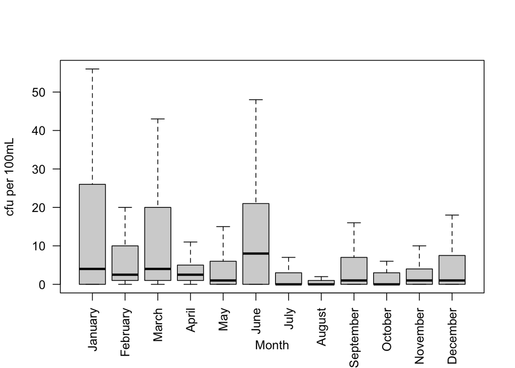

```r
#par(mfrow = c(1,2))
month = data$Month
cfu = data$Enterococci..cfu.100ml.
month = factor(month, levels = c('January','February','March','April','May','June','July','August','September','October','November','December'))
## eliminate the extremes
boxplot(cfu ~ month, las = 2, outline = F, ylab = 'cfu per 100mL', xlab = 'Month')
```

- Analysis: The biggest median of enterococci cfu is in June, the maximum scores in January, March, and June are more bigger than others, which means in these three months, water quality used to be very bad. In January, March, and June, the boxes are much longer than others, so there are more dispersed data, the water quality might be very unstable for some reasons.And most boxes are not symmetric but right-skewed.They are not normally distributed.
- Additional research and summary: From the 2021-2022 report of water quality, ‘Rainfall is the major driver of pollution to recreational waters,generating stormwater runoff and triggering untreated discharges from the wastewater treatment and transport systems.’(State of the beaches 2021–22, 2022,p.5), and also I researched that the distribution of rainfall is between November to March<sup>2</sup>. So the conclusion is that the bigger maximum scores and more dispersed data caused by the climate reason, but the situation about the June can’t be explained very well.

**The relationship between the sites and the enterococci cfu per 100mL**

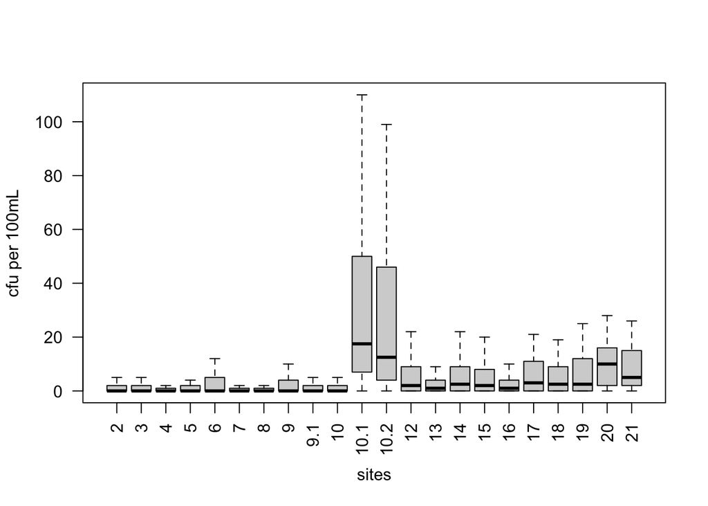

```r
## Because the names of beach sites are too long, I will use BeachID to replace the variable.
sites = data$BeachId
#n = table(sites)
#print(n)
boxplot(cfu ~ sites, las = 2, outline = F, ylab = 'cfu per 100mL')
```

- Analysis: Most beaches have a very low median, but the medians of Bilarong Reserve (Narrabeen Lagoon)(10.2) and Birdwood Park (Narrabeen Lagoon)(10.1) are much bigger than others. And the two sites in Narrabeen Lagoon are more sparse.Also both have higher maximum scores. And data of almost every beach is not normally distributed. The mean of samples of Narrabeen Lagoon should be same, we do a hypothesis test.
  - Hypothesis Test:
  - H0: There is no difference of means of sample of Bilarong Reserve (Narrabeen Lagoon)(10.2) and the sample of Birdwood Park (Narrabeen Lagoon)(10.1).
  - H1:There is a difference between the means of two samples of Birdwood Park (Narrabeen Lagoon)(10.1) and Bilarong Reserve (Narrabeen Lagoon)(10.2)
  - Assumption(Week11 Lecture2):  
    1.All observed individuls are independent  
    2.Two samples have same spread.  
    3.Two sample means follow normal distribution  
    4.The significant level is 0.05
  - Conclusion:  
    we can see that the p-value is 0.207 is bigger than the significant level 0.05, so we do not reject the null hypothesis.

```r
## select specific rows
diff_1 = data[data$BeachId == 10.1, ]
diff_2 = data[data$BeachId == 10.2, ]
a1 = diff_1$Enterococci..cfu.100ml.
a2 = diff_2$Enterococci..cfu.100ml.
n1 = length(a1)
n2 = length(a2)
m1 = mean(a1)
m2 = mean(a2)
sdp2 = ((n1-1)*sd(a1)^2+(n2-1)*sd(a2)^2)/(n1 + n2 -2)
se = sqrt(sdp2*(1/n1+1/n2))
Teststat = (m1-m2-0)/se

Pvalue = 2*pt(abs(Teststat), n1+n2-2, lower.tail = F)
print(c(Pvalue, Teststat))
```

```
## [1] 0.2070082 1.2690498
```

```r
## Check
c = t.test(a1,a2,var.equal = T)
print(c)
```

```
##
##  Two Sample t-test
##
## data:  a1 and a2
## t = 1.269, df = 114, p-value = 0.207
## alternative hypothesis: true difference in means is not equal to 0
## 95 percent confidence interval:
##  -67.53331 308.29194
## sample estimates:
## mean of x mean of y
## 171.62069  51.24138
```

# 3 References

1.https://www.environment.nsw.gov.au/-/media/OEH/Corporate-Site/Documents/Water/Beaches/State-of-the-Beaches/state-of-beaches-2021-2022-statewide-summary-220317.pdf  
2.http://www.bom.gov.au/climate/current/annual/aus/#tabs=Rainfall  
3.https://www.environment.nsw.gov.au/topics/water/estuaries/estuaries-of-nsw/narrabeen-lagoon